# Statistical Inference Project Part 1 - A Simulation Exercise

#### Author: *Utkarsh Ashok Pathrabe*

## Overview:

This project investigates the Exponential distribution in R and compares it with the Central Limit Theorem. The mean of the Exponential distribution is $\frac{1}{\lambda}$ and the standard deviation is also $\frac{1}{\lambda}$. A thousand simulations of the distribution of 40 exponentials would be investigated.

## Simulations:

The exponential distribution can be simulated in R with `rexp(n, lambda)`, where `lambda` is the rate parameter and `n` is the number of observations. For the purpose of all the simulations in this project, value of `lambda` is set to `0.2`.  
First we load the `ggplot2` plotting library.

```r
library(ggplot2)
```

We then initialize the simulation controlling variables.

```r
noSim <- 1000
sampSize <- 40
lambda <- 0.2
```

Set the seed of the Random Number Generator, so that the analysis is reproducible.

```r
set.seed(3)
```

Create a matrix with thousand rows corresponding to 1000 simulations and forty columns corresponding to each of 40 random simulations.

```r
simulationMatrix <- matrix(rexp(n = noSim * sampSize, rate = lambda), noSim, sampSize)
```

Create a vector of thousand rows containing the mean of each row of the `simulationMatrix`.

```r
simulationMean <- rowMeans(simulationMatrix)
```

Create a data frame containing the whole data.

```r
simulationData <- data.frame(cbind(simulationMatrix, simulationMean))
```

We plot the simulation data to visualize it.

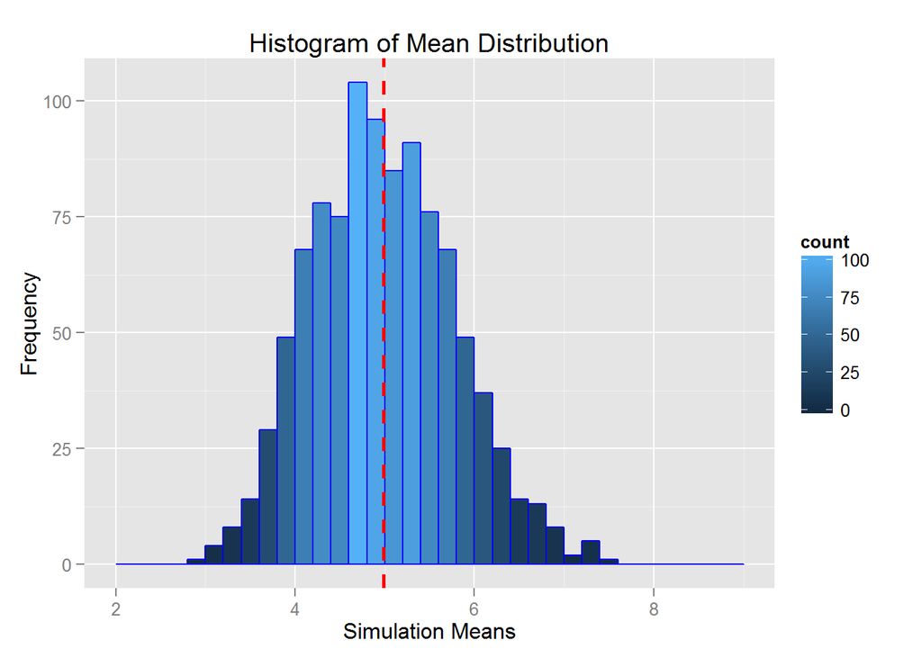

```r
ggplot(data = simulationData, aes(simulationData$simulationMean)) +
  geom_histogram(breaks = seq(2, 9, by = 0.2), col = "blue", aes(fill = ..count..)) +
  labs(title = "Histogram of Mean Distribution", x = "Simulation Means", y = "Frequency") +
  geom_vline(aes(xintercept=mean(simulationData$simulationMean)), color="red",
             linetype="dashed", size=1)
```

## Sample Mean Versus Theoretical Mean:

The actual mean of the simulated mean sample data is 4.9866197, calculated by:

```r
actualMean <- mean(simulationMean)
```

And the theoretical mean is 5, calculated by:

```r
theoreticalMean <- (1 / lambda)
```

Thus, we can see that the actual mean of the simulated mean sample data is very close to the theoretical mean of original data distribution.

## Sample Variance Versus Theoretical Variance:

The actual variance of the simulated mean sample data is 0.6257575, calculated by:

```r
actualVariance <- var(simulationMean)
```

And the theoretical variance is 0.625, calculated by:

```r
theoreticalVariance <- ((1 / lambda) ^ 2) / sampSize
```

Thus, we can see that the actual variance of the simulated mean sample data is very close to the theoretical variance of original data distribution.